# R Notebook

Data Understanding:

Data taken from: https://www.kaggle.com/drgilermo/nba-players-stats/data the column names and their descriptions are also there

First, I removed the blank fields.

I then decided to remove any fields with missing data

After examining data I have decided I am only considering seasons after 1975 because seasons before that are missing some stats that the NBA did not record at that time. Also, I decided to only count seasons for which a player played more than 40 games. I will be adding a field, improvement, to measure the improvement of a player’s PPG from this season to the season they played the year previous because I would like some sort of representation of how the player has been improving/progressing. I am also adding the variable that we are going to try and predict: NextSeasonChange which is the percentage increase or decrease of the player’s points per game for the next season

```r
data <- read.csv("data/Seasons_Stats.csv")
drops <- c("blanl","blank2")
data <- data[ , !(names(data) %in% drops)]
data <- data[complete.cases(data), ]
data <- data[data$Year > 1975 & !is.na(data$Year),]
data <- data[order(data$Player, data$Age),]
data <- data[data$G > 40,]
data$Improvement <- NA
data$NextSeasonChange <- NA
```

Converting everything from totals to per game stats to make it easier to evaluate the features

```r
total_stats <- c("MP", "FT", "FTA", "ORB", "DRB", "TRB", "AST", "STL", "BLK", "TOV", "PF", "PTS", "FG", "FGA", "X2P", "X2PA", "X3P", "X3PA")
for (stat_name in total_stats) {
  data[[stat_name]] <- round(data[[stat_name]] / data$G, digits = 1)
}
```

I changed the fields that are percentages to be decimals.

55.3% -> .553

```r
percentages <- c("ORB.", "DRB.", "TRB.", "AST.", "STL.", "BLK.", "TOV.", "USG.")
for (stat_name in percentages) {
  data[[stat_name]] <- data[[stat_name]] / 100
}
```

```r
summary(data)
```

```
       X              Year                   Player           Pos            Age
 Min.   : 5730   Min.   :1980   Eddie Johnson   :   22   PG     :2242   Min.   :18.00
 1st Qu.:10585   1st Qu.:1992   Gerald Henderson:   22   SG     :2219   1st Qu.:24.00
 Median :15254   Median :2001   Kevin Willis    :   22   SF     :2167   Median :26.00
 Mean   :15315   Mean   :2001   Kevin Garnett   :   21   PF     :2085   Mean   :26.89
 3rd Qu.:19974   3rd Qu.:2010   Vince Carter    :   21   C      :1508   3rd Qu.:30.00
 Max.   :24689   Max.   :2017   Jason Kidd      :   20   SF-SG  :  20   Max.   :41.00
                                (Other)         :10211   (Other):  98
       Tm             G               GS              MP             PER
 TOT    : 913   Min.   :41.00   Min.   : 0.00   Min.   : 3.00   Min.   : 0.90
 IND    : 372   1st Qu.:58.00   1st Qu.: 6.00   1st Qu.:17.60   1st Qu.:11.50
 SAS    : 358   Median :72.00   Median :31.00   Median :24.60   Median :13.90
 UTA    : 354   Mean   :68.14   Mean   :36.11   Mean   :24.64   Mean   :14.18
 BOS    : 352   3rd Qu.:79.00   3rd Qu.:67.00   3rd Qu.:32.10   3rd Qu.:16.40
 HOU    : 351   Max.   :85.00   Max.   :83.00   Max.   :43.70   Max.   :31.70
 (Other):7639
      TS.             X3PAr             FTr              ORB.              DRB.
 Min.   :0.2380   Min.   :0.0010   Min.   :0.0230   Min.   :0.00000   Min.   :0.0290
 1st Qu.:0.4980   1st Qu.:0.0150   1st Qu.:0.2080   1st Qu.:0.02500   1st Qu.:0.0900
 Median :0.5280   Median :0.1130   Median :0.2820   Median :0.04700   Median :0.1220
 Mean   :0.5263   Mean   :0.1791   Mean   :0.3005   Mean   :0.05558   Mean   :0.1345
 3rd Qu.:0.5560   3rd Qu.:0.3140   3rd Qu.:0.3720   3rd Qu.:0.08150   3rd Qu.:0.1730
 Max.   :0.7250   Max.   :0.8910   Max.   :1.2340   Max.   :0.20800   Max.   :0.3780

      TRB.              AST.            STL.              BLK.              TOV.
 Min.   :0.02400   Min.   :0.009   Min.   :0.00200   Min.   :0.00000   Min.   :0.0180
 1st Qu.:0.05900   1st Qu.:0.078   1st Qu.:0.01200   1st Qu.:0.00400   1st Qu.:0.1120
 Median :0.08500   Median :0.120   Median :0.01600   Median :0.00900   Median :0.1350
 Mean   :0.09506   Mean   :0.148   Mean   :0.01713   Mean   :0.01326   Mean   :0.1396
 3rd Qu.:0.12700   3rd Qu.:0.200   3rd Qu.:0.02100   3rd Qu.:0.01700   3rd Qu.:0.1620
 Max.   :0.29700   Max.   :0.575   Max.   :0.05800   Max.   :0.10800   Max.   :0.3480

      USG.             OWS              DWS               WS             WS.48
 Min.   :0.0420   Min.   :-3.300   Min.   :-1.000   Min.   :-2.100   Min.   :-0.08900
 1st Qu.:0.1620   1st Qu.: 0.400   1st Qu.: 0.800   1st Qu.: 1.400   1st Qu.: 0.05800
 Median :0.1920   Median : 1.400   Median : 1.400   Median : 3.000   Median : 0.09100
 Mean   :0.1944   Mean   : 1.989   Mean   : 1.735   Mean   : 3.724   Mean   : 0.09233
 3rd Qu.:0.2240   3rd Qu.: 3.000   3rd Qu.: 2.400   3rd Qu.: 5.300   3rd Qu.: 0.12400
 Max.   :0.4170   Max.   :15.200   Max.   : 9.100   Max.   :21.200   Max.   : 0.32200

```

[output cut: 32 more lines]

```
      AST              STL              BLK              TOV              PF
 Min.   : 0.000   Min.   :0.0000   Min.   :0.0000   Min.   :0.000   Min.   :0.200
 1st Qu.: 1.000   1st Qu.:0.5000   1st Qu.:0.1000   1st Qu.:0.900   1st Qu.:1.700
 Median : 1.800   Median :0.7000   Median :0.3000   Median :1.400   Median :2.200
 Mean   : 2.444   Mean   :0.8382   Mean   :0.4651   Mean   :1.528   Mean   :2.205
 3rd Qu.: 3.200   3rd Qu.:1.1000   3rd Qu.:0.6000   3rd Qu.:2.000   3rd Qu.:2.700
 Max.   :14.500   Max.   :3.7000   Max.   :5.0000   Max.   :5.700   Max.   :4.800

      PTS        Improvement    NextSeasonChange
 Min.   : 0.60   Mode:logical   Mode:logical
 1st Qu.: 5.80   NA's:10339     NA's:10339
 Median : 9.30
 Mean   :10.49
 3rd Qu.:14.10
 Max.   :37.10
```

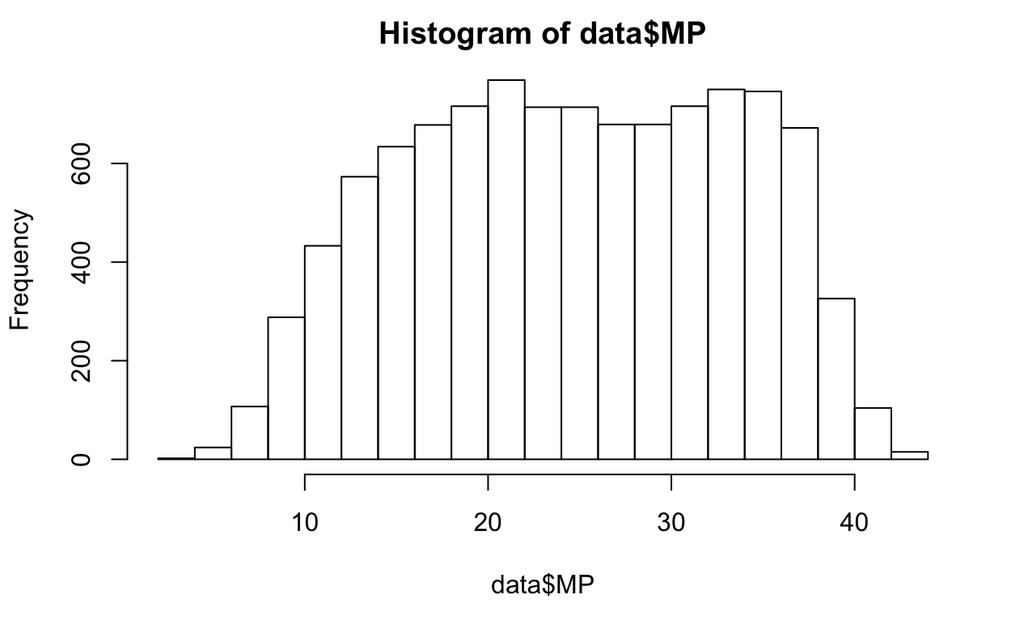

```r
hist(data$MP)
```

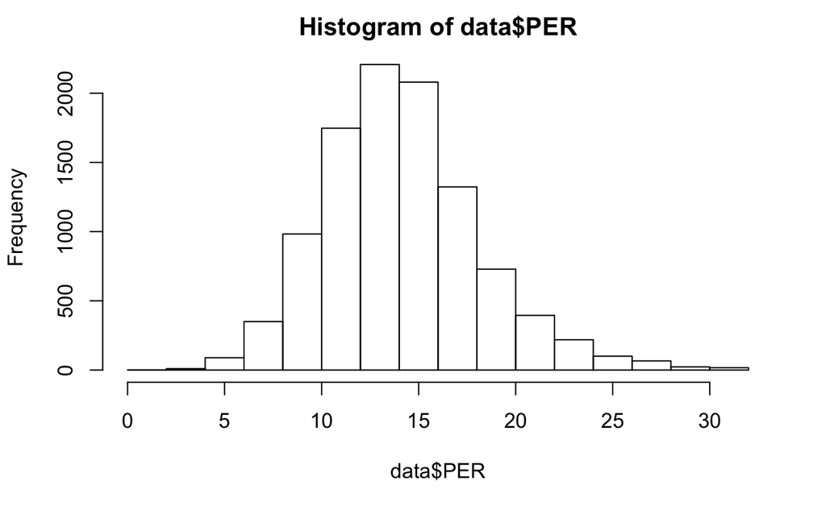

```r
hist(data$PER)
```

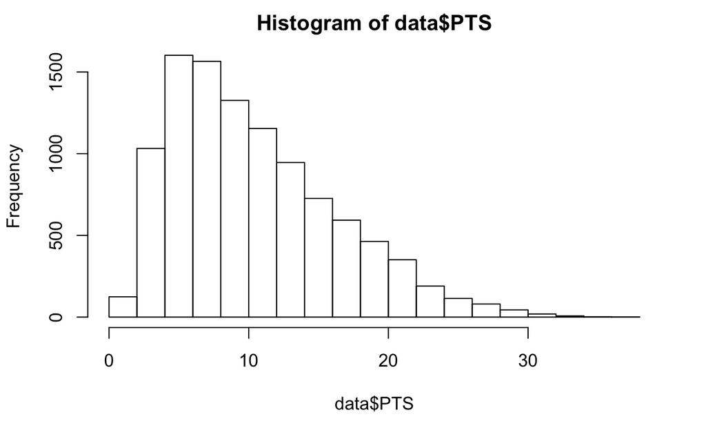

```r
hist(data$PTS)
```

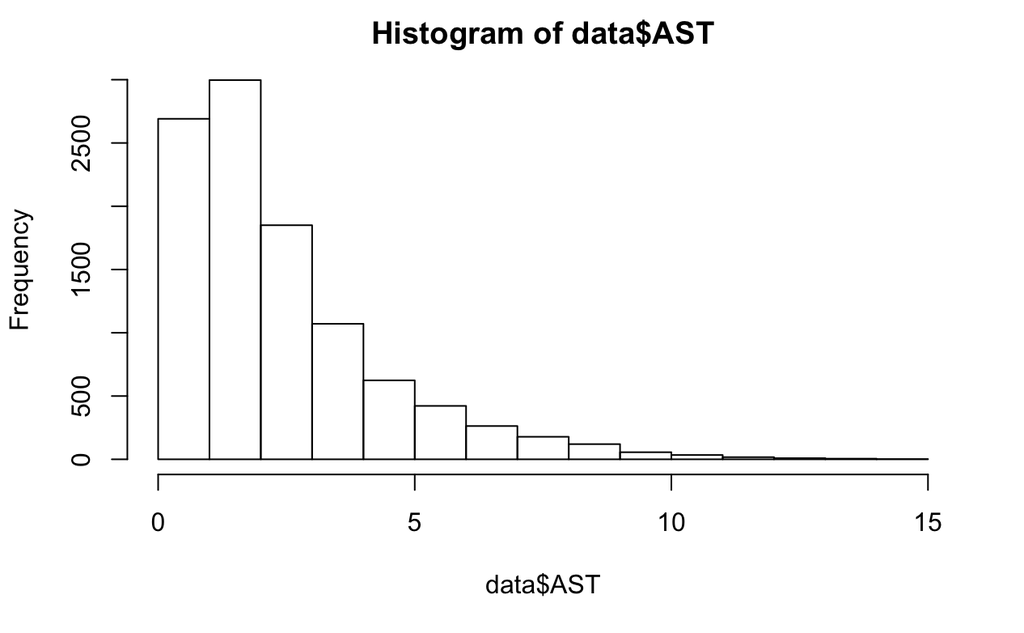

```r
hist(data$AST)
```

```r
sd_mpg <- sd(data$MP)
mean_mpg <- mean(data$MP)
mpg_outliers <- c()
for (i in 1:length(data$MP)) {
  if((abs(data$MP[i] - mean_mpg) / sd_mpg) > 3) {
    mpg_outliers <- append(data$X[i], mpg_outliers)
  }
}
sd_pts <- sd(data$PTS)
mean_pts <- mean(data$PTS)
pts_outliers <- c()
for (i in 1:length(data$PTS)) {
  if((abs(data$PTS[i] - mean_pts) / sd_pts) > 3) {
    pts_outliers <- append(data$X[i], pts_outliers)
  }
}
sd_ast <- sd(data$AST)
mean_ast <- mean(data$AST)
ast_outliers <- c()
for (i in 1:length(data$AST)) {
  if((abs(data$AST[i] - mean_ast) / sd_ast) > 3) {
    ast_outliers <- append(data$X[i], ast_outliers)
  }
}
sd_ast <- sd(data$AST)
mean_ast <- mean(data$AST)
ast_outliers <- c()
for (i in 1:length(data$AST)) {
  if((abs(data$AST[i] - mean_ast) / sd_ast) > 3) {
    ast_outliers <- append(data$X[i], ast_outliers)
  }
}
```

In order to deal with players who switched teams, we will remove the rows for the stats of each individual team the player played for that season and only keep the row for that season that represents the aggregated stats over all teams the player played with that season.

For example, the rows for a player’s season where he got traded might look like: name, Team, year, GamesPlayed

player1 LAL 2018 50

player1 GSW 2018 20

player1 TOT 2018 70

but would become:

player1 TOT 2018 70

```r
data$PlayerAndYear <- paste(data$Player, data$Year, sep = "-")
for (x in unique(data$PlayerAndYear)) {
  da <- data[data$PlayerAndYear == x,]
  if (nrow(da) > 1) {
    da <- da[da$Tm != "TOT",]$X
    data <- data[!(data$X %in% da),]
  }
}
```

In this we will find rows that have a previous season and following season for the same player and previous and next years. Then we will add an improvement percentage that corresponds to how much the player’s PPG improved compared to the previous season. Lastly, we will add the variable we will be predicting, NextSeasonChange, which is the % change in PPG the next season

```r
for (row_index in 2:(nrow(data) - 1)) {
  curr_row <- data[row_index,]
  prev_row <- data[row_index-1,]
  next_row <- data[row_index+1,]
  if(prev_row$Player == curr_row$Player & (prev_row$Year + 1) == curr_row$Year &
    next_row$Player == curr_row$Player & (next_row$Year - 1) == curr_row$Year) {
    data$Improvement[row_index] = (curr_row$PTS / prev_row$PTS) - 1
    data$NextSeasonChange[row_index] = (next_row$PTS / curr_row$PTS) - 1
  }
}
```

Now we will keep all the rows that have the NextSeasonChange field and also remove the PlayerAndYear field that we used in order clean data for players that were traded.

```r
data <- data[!(is.na(data$NextSeasonChange)),]
data <- data[ , !(names(data) %in% c("PlayerAndYear"))]
```

```r
summary(data)
```

```
       X              Year                 Player          Pos            Age
 Min.   : 6091   Min.   :1981   Kevin Garnett :  18   PG     :1227   Min.   :19.00
 1st Qu.:10767   1st Qu.:1992   Dirk Nowitzki :  17   SG     :1214   1st Qu.:25.00
 Median :15287   Median :2001   Jason Kidd    :  17   SF     :1156   Median :27.00
 Mean   :15247   Mean   :2000   John Stockton*:  17   PF     :1027   Mean   :27.27
 3rd Qu.:19605   3rd Qu.:2009   Karl Malone*  :  17   C      : 614   3rd Qu.:30.00
 Max.   :24093   Max.   :2016   Tim Duncan    :  17   PG-SG  :  13   Max.   :40.00
                                (Other)       :5202   (Other):  54
       Tm             G               GS              MP             PER
 TOT    : 454   Min.   :41.00   Min.   : 0.00   Min.   : 3.60   Min.   : 3.00
 IND    : 213   1st Qu.:66.00   1st Qu.:14.00   1st Qu.:22.20   1st Qu.:12.60
 POR    : 203   Median :76.00   Median :51.00   Median :29.00   Median :14.90
 SAS    : 203   Mean   :71.68   Mean   :45.58   Mean   :27.96   Mean   :15.31
 LAL    : 196   3rd Qu.:81.00   3rd Qu.:76.00   3rd Qu.:34.50   3rd Qu.:17.50
 DET    : 194   Max.   :85.00   Max.   :83.00   Max.   :43.70   Max.   :31.70
 (Other):3842
      TS.             X3PAr             FTr              ORB.              DRB.
 Min.   :0.3240   Min.   :0.0010   Min.   :0.0340   Min.   :0.00200   Min.   :0.0320
 1st Qu.:0.5080   1st Qu.:0.0220   1st Qu.:0.2150   1st Qu.:0.02400   1st Qu.:0.0890
 Median :0.5340   Median :0.1510   Median :0.2850   Median :0.04300   Median :0.1190
 Mean   :0.5346   Mean   :0.1887   Mean   :0.3014   Mean   :0.05202   Mean   :0.1331
 3rd Qu.:0.5620   3rd Qu.:0.3210   3rd Qu.:0.3690   3rd Qu.:0.07500   3rd Qu.:0.1710
 Max.   :0.6990   Max.   :0.8730   Max.   :1.2190   Max.   :0.20800   Max.   :0.3780

      TRB.              AST.            STL.              BLK.              TOV.
 Min.   :0.02400   Min.   :0.009   Min.   :0.00200   Min.   :0.00000   Min.   :0.0260
 1st Qu.:0.05800   1st Qu.:0.090   1st Qu.:0.01300   1st Qu.:0.00400   1st Qu.:0.1100
 Median :0.08200   Median :0.134   Median :0.01700   Median :0.00800   Median :0.1300
 Mean   :0.09268   Mean   :0.163   Mean   :0.01769   Mean   :0.01247   Mean   :0.1348
 3rd Qu.:0.12300   3rd Qu.:0.219   3rd Qu.:0.02200   3rd Qu.:0.01600   3rd Qu.:0.1550
 Max.   :0.29700   Max.   :0.575   Max.   :0.05800   Max.   :0.10800   Max.   :0.3200

      USG.             OWS              DWS               WS             WS.48
 Min.   :0.0630   Min.   :-2.700   Min.   :-1.000   Min.   :-1.500   Min.   :-0.0790
 1st Qu.:0.1690   1st Qu.: 1.000   1st Qu.: 1.100   1st Qu.: 2.400   1st Qu.: 0.0730
 Median :0.1990   Median : 2.200   Median : 1.800   Median : 4.200   Median : 0.1040
 Mean   :0.2024   Mean   : 2.749   Mean   : 2.093   Mean   : 4.843   Mean   : 0.1069
 3rd Qu.:0.2340   3rd Qu.: 4.000   3rd Qu.: 2.800   3rd Qu.: 6.600   3rd Qu.: 0.1380
 Max.   :0.3870   Max.   :15.200   Max.   : 9.100   Max.   :21.200   Max.   : 0.3220

```

[output cut: 32 more lines]

```
      AST              STL              BLK              TOV              PF
 Min.   : 0.100   Min.   :0.1000   Min.   :0.0000   Min.   :0.100   Min.   :0.300
 1st Qu.: 1.400   1st Qu.:0.6000   1st Qu.:0.2000   1st Qu.:1.100   1st Qu.:1.800
 Median : 2.400   Median :0.9000   Median :0.3000   Median :1.600   Median :2.300
 Mean   : 2.979   Mean   :0.9791   Mean   :0.5004   Mean   :1.747   Mean   :2.333
 3rd Qu.: 3.900   3rd Qu.:1.2000   3rd Qu.:0.6000   3rd Qu.:2.300   3rd Qu.:2.800
 Max.   :14.500   Max.   :3.7000   Max.   :4.6000   Max.   :4.700   Max.   :4.600

      PTS         Improvement       NextSeasonChange
 Min.   : 0.60   Min.   :-0.81250   Min.   :-0.812500
 1st Qu.: 7.70   1st Qu.:-0.15278   1st Qu.:-0.197115
 Median :11.70   Median : 0.00565   Median :-0.035714
 Mean   :12.44   Mean   : 0.08497   Mean   : 0.008667
 3rd Qu.:16.40   3rd Qu.: 0.21818   3rd Qu.: 0.138298
 Max.   :35.40   Max.   : 3.50000   Max.   : 4.681818
```

```r
data <- data[ , !(names(data) %in% c("X3PAr"))]
```

Parsing Position text to make it only use first mentioned position

PG-SG -> PG

Then, converted it to dummy codes I didn’t include PF as a new field because we need (num categories - 1) dummy codes

```r
data$Pos <- gsub("-.*", "", data$Pos)
positions <- c("PG", "SG", "SF", "C")
for (position in positions) {
  data[[position]] <- as.numeric(data$Pos == position)
}
data <- data[ , !(names(data) %in% c("Pos"))]
```

Next, we must convert team to dummy codes as well.

```r
teams <- unique(data$Tm)
for (team in teams[1:(length(teams) - 1)]) {
  data[[team]] <- as.numeric(data$Tm == team)
}
data <- data[ , !(names(data) %in% c("Tm"))]
```

Here I test the correlation between Improvement and NextSeasonChange, and NextSeasonChange and age.

I hypothesize that if you improve 1 year you may continue to improve, or that as you get older you improve less. However, I am shown very very small correlations for the two tests. I used pearson because all 3 features are generally normal looking

```r
cor.test(data$NextSeasonChange, y=data$Improvement)
```

```
    Pearson's product-moment correlation

data:  data$NextSeasonChange and data$Improvement
t = -9.3946, df = 5303, p-value < 2.2e-16
alternative hypothesis: true correlation is not equal to 0
95 percent confidence interval:
 -0.1543275 -0.1013867
sample estimates:
       cor
-0.1279482
```

```r
cor.test(data$NextSeasonChange, y=data$Age)
```

```
    Pearson's product-moment correlation

data:  data$NextSeasonChange and data$Age
t = -16.129, df = 5303, p-value < 2.2e-16
alternative hypothesis: true correlation is not equal to 0
95 percent confidence interval:
 -0.2417539 -0.1904479
sample estimates:
       cor
-0.2162502
```

Now I write the prepared data to a new file

```r
write.csv(data, file= "data/formatted_season_data.csv")
```